# ML Assignment 2: NHANES data

Imran Aziz

Conrard G. T. Feugmo

Andre Schardong

Milton Segura

Sarpreet Gill

York University School of Continuing Studies

Nov 15, 2019

# 1 Introduction

Our client, a hypothetical pharmaceutical company, is looking to understand better what the data related to individuals (clients and potential clients) and various health conditions and miscellaneous attributes. The goal is to extract meaningful information that could guide future research and assist with the company rapidly expanding business and market share while focusing on and improving the wellbeing of the clients.

## 1.1 Terms and defenitions

- **Individual** - A person who has been surveyed by the NHMS (National Health Measurement Study) dataset for various attributes related to the following: demographics, examinations, dietary, questionnaire (medical history), and medication.
- **Health Conditions** - Various diseases or ailments that people may inhibit, such as sleep disorders, diabetes, oral health, cholesterol.
- **The National Health and Nutrition Examination Survey (NHANES)** - A program of studies designed to assess the health and nutritional status of adults and children in the United States.

## 1.2 Data Description

The data gettered is spread into six distinct files (CSV format): Demographics, Examinations, Dietary, Laboratory, Questionnaire, and Medication.

# 2 Business Case

Our client wants to develop new drugs that primary intent to improve the quality of life of the individuals survived. The company is interested as to whether existing data on subjects and their associated health conditions could provide advice and insight to their researcher. They have obtained the NHANES dataset and requested our assistance to perform the intended analysis. This dataset contains individuals data along with various information, including health conditions.

The company, aware of our Machine Learning skills, approached us for help on the following problems:

## 2.1 First Problem: Development of Drugs

The company has a mature R&D function in relation to other pharmaceutical companies. However, the researchers are looking for any type of edge or extra tidbit of information that might be beneficial to the researchers to develop their drugs for diabetes, hypertension, and cancer. Also, the clinical trials are increasingly expensive for the development of new drugs for the treatment of diseases. Is there anything in the data that could help us lower the costs?

## 2.2 Second Problem: Marketing

The marketing department is struggling with high costs of television advertisements and is interested in ways to reduce their costs while still hitting their target markets for both the advertisement of drugs and attracting candidates for trails.

## 2.3 Third Problem: Reduce lab costs and create referral lists

For candidates already enrolled in Diabetes program, is there a way to tell if they have other diseases such as cancer or hypertension with the minimum amount of questions? The cost of performing lab costs could be reduced and if the candidates does have another disease, they could be used as a referral into another drug testing plan for that disease.

The company would ask us about possible wraping the model as a robust, easy to use App that could be present to managment and corporate to assist with the decision making, based on a few user inputs.

# 3 Analytical Reframing for the Business Case.

The **first business problem** involves finding commonality between individuals. This is a clustering problem and we will need a model using a clustering algorithm. We need to determine whether the business’s presumption is accurate:

- According to their health conditions, can subjects be divided into discrete groups that could provide meaningful data for the drug researchers?
- Can this information be useful to reduce the costs of clinical trials?
- We’re comparing the columns of the dataset.

If this is the case, we need to find clusters of subjects that segregate the data by health conditions and report these findings to the business.

The **second business problem** involves using “health condition” features and finding related features. This is an association problem and we will need a model using an association algorithm. For this, we only need to use diet and demographic data potentially. This is a marketing problem so other attributes may not be applicable.

- What features are associated with “health condition” features?
- We’re comparing the rows of the dataset.

The **third business problem** is a supervised machine learning problem. Using the least amount of information, if a individual has diabetes, can we predict whether they have either hypertension or cancer (or both)?

## 3.1 How do we define “health condition” features within the dataset ?

For the association problem, we will need to see which attributes are tied to the “health condition” features. In order to achieve this, we are postulating that the following columns/features of the Questionnaire dataset indicate that an individual has a “health condition”:

### 3.1.1 Diabetes

DIQ010 - Doctor told you have diabetes https://wwwn.cdc.gov/Nchs/Nhanes/2013-2014/DIQ_H.htm The next questions are about specific medical conditions. {Other than during pregnancy, {have you/has SP}/{Have you/Has SP}} ever been told by a doctor or health professional that {you have/{he/she/SP} has} diabetes or sugar diabetes?

### 3.1.2 Hypertension(bllod pressure)

BPQ020 - Ever told you had high blood pressure https://wwwn.cdc.gov/Nchs/Nhanes/2013-2014/BPQ_H.htm {Have you/Has SP} ever been told by a doctor or other health professional that {you/s/he} had hypertension, also called high blood pressure?

### 3.1.3 Cancer

MCQ220 - Ever told you had cancer or malignancy https://wwwn.cdc.gov/Nchs/Nhanes/2013-2014/MCQ_H.htm#MCQ220 {Have you/Has SP} ever been told by a doctor or other health professional that {you/s/he} had cancer or a malignancy (ma-lig-nan-see) of any kind?

# 4 Loading R packages

```r
library(plyr)
library(dplyr)
library(tidyr)
library(ggplot2)
library(knitr)
library(mice)
library(scales)
library(randomForest)
library(psych)
library(factoextra)
library(RColorBrewer)
library(caret)
library(plotly)
library(scales)
library(AMR)
```

# 5 Data cleaning

As indicated earlier, the dataset consists of six raw data files: Demographics, Examinations, Dietary, Laboratory, Questionnaire, and Medication. The largest dataset, in terms of attributes, contains 953 variables, while the smallest one contains 47 variables.

Because this is a large amount of data, with over a thousand attributes cumulatively, we decided to employ the following guidelines to reduce the complexity of the data:

- If more than 25% of the values are missing for an attribute(column), we will consider removing the column from further evaluation.
- If the majority of attributes are missing 25% or more of their values for a given dataset, we will use business and expert judgement to select a smaller subset of values of interest subjectively. Of these subsets of missing values, we will decide how to impute the values on these attributes.

Ideally, we would like to analyze and impute every attribute with missing values, but in this situation, it may not be practical due to the large volume of missing data.

`{eval=FALSE, r, warning = F, message=F} # Reading files demographic = read.csv("Data/Raw/demographic.csv", header = TRUE, na.strings = c("NA","","#NA")) diet = read.csv("Data/Raw/diet.csv", header = TRUE, na.strings = c("NA","","#NA")) examination = read.csv("Data/Raw/examination.csv", header = TRUE, na.strings = c("NA","","#NA")) labs = read.csv("Data/Raw/labs.csv", header = TRUE, na.strings = c("NA","","#NA")) medications = read.csv("Data/Raw/medications.csv", header = TRUE, na.strings = c("NA","","#NA")) questionnaire = read.csv("Data/Raw/questionnaire.csv", header = TRUE, na.strings = c("NA","","#NA")) # Merging files data_list = list(demographic,examination,diet,labs,questionnaire,medications) data_joined = join_all(data_list)`

## 5.1 Checking for missing data

It is always essentialto check for missing values and consider how to addreess them in the model.

We found that the percentage of missing data in four of the six spreadsheets is very significant. Almost all attributes/columns have varying degrees of missing values.

### 5.1.1 Demographic

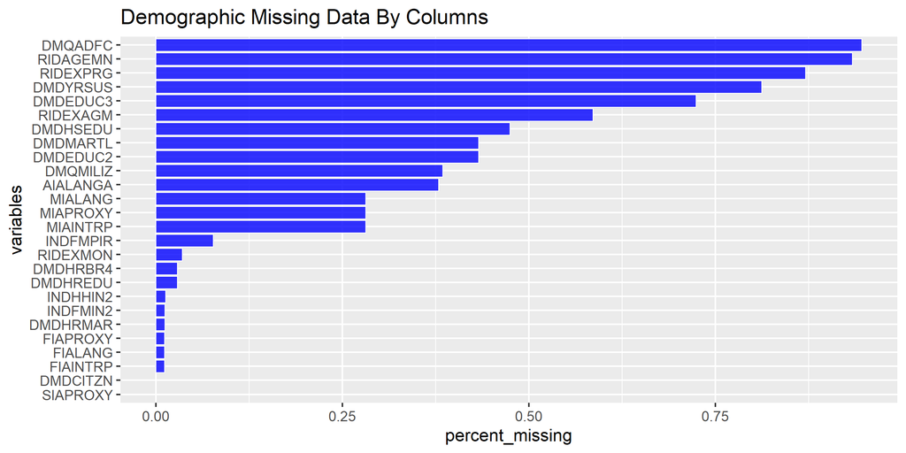

```r
demographic_MS <- demographic %>% summarise_all(~(sum(is.na(.))/n()))
demographic_MS <- gather(demographic_MS, key = "variables", value = "percent_missing")
demographic_MS <- demographic_MS[demographic_MS$percent_missing > 0.0, ]
demographic_MS_plot  <- ggplot(demographic_MS, aes(x = reorder(variables,percent_missing),
                                                   y = percent_missing)) +
  geom_bar(stat = "identity", fill = "blue", aes(color = I('white')),
           size = 0.3, alpha = 0.8)+
  xlab('variables')+ coord_flip()+
  #theme_fivethirtyeight() +
  ggtitle("Demographic Missing Data By Columns")
#demographic_MS_plot
ggsave(plot = demographic_MS_plot, width = 8, height = 4, dpi = 300,
       filename = "Figures/demographic_MS_plot.png")
```

### 5.1.2 Diet

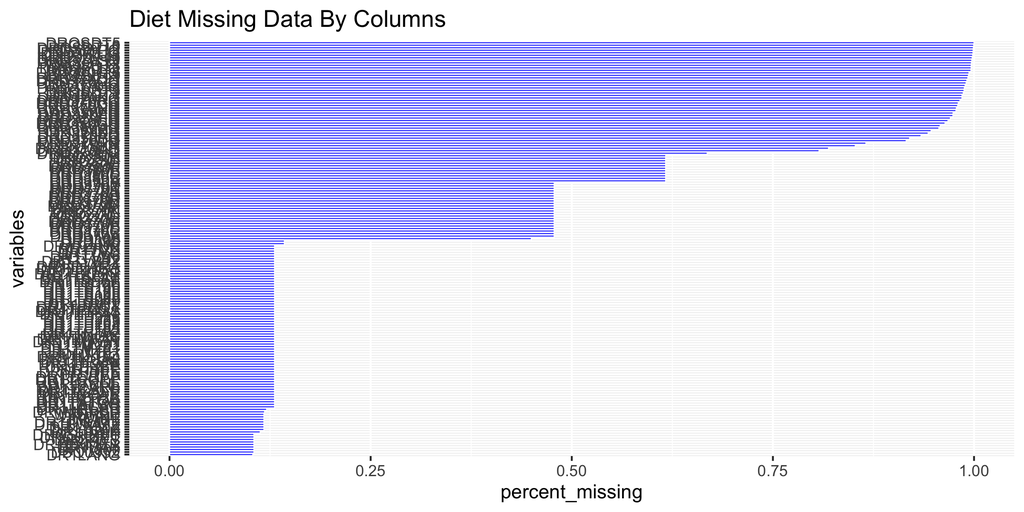

```r
diet_MS <- diet %>% summarise_all(~(sum(is.na(.))/n()))
diet_MS <- gather(diet_MS, key = "variables", value = "percent_missing")
diet_MS <- diet_MS[diet_MS$percent_missing > 0.0, ]
diet_MS_plot <- ggplot(diet_MS, aes(x = reorder(variables, percent_missing),
                                    y = percent_missing)
                       ) +
  geom_bar(stat = "identity", fill = "blue", aes(color = I('blue')),
           size = 0.3, alpha = 0.8)+
  xlab('variables') + coord_flip()+
  #theme_fivethirtyeight() +
  ggtitle("Diet Missing Data By Columns")+
  theme(axis.text.y=element_text(size=3))
#diet_MS_plot
ggsave(plot = diet_MS_plot, width = 8, height = 4, dpi = 300,
       filename = "Figures/diet_MS_plot.png")
```

### 5.1.3 Examination

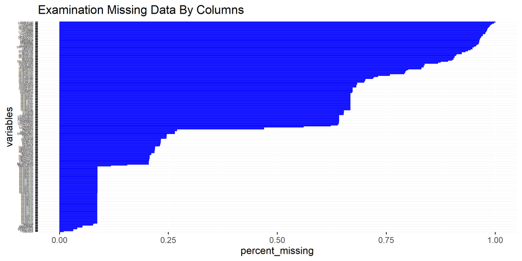

```r
examination_MS <- examination %>% summarise_all(~(sum(is.na(.))/n()))
examination_MS <- gather(examination_MS, key = "variables", value = "percent_missing")
examination_MS <- examination_MS[examination_MS$percent_missing > 0.0, ]
examination_MS_plot <- ggplot(examination_MS, aes(x = reorder(variables, percent_missing),
                                                  y = percent_missing)) +
  geom_bar(stat = "identity", fill = "blue", aes(color = I('blue')),
           size = 0.3, alpha = 0.8)+
  xlab('variables')+ coord_flip()+
  #theme_fivethirtyeight() +
  ggtitle("Examination Missing Data By Columns")+
  theme(axis.text.y=element_text(size=3))
#examination_MS_plot
ggsave(plot = examination_MS_plot, width = 8, height = 4, dpi = 300,
       filename = "Figures/examination_MS_plot.png")
```

### 5.1.4 Labs

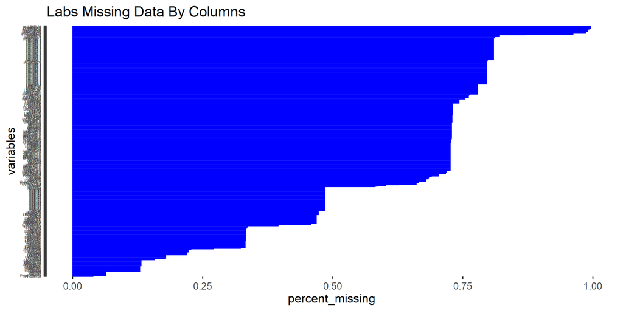

```r
labs_MS <- labs %>% summarise_all(~(sum(is.na(.))/n()))
labs_MS <- gather(labs_MS, key = "variables", value = "percent_missing")
labs_MS <- labs_MS[labs_MS$percent_missing > 0.0, ]
labs_MS_plot <- ggplot(labs_MS, aes(x = reorder(variables, percent_missing),
                                    y = percent_missing)
                       ) +
  geom_bar(stat = "identity", fill = "blue", aes(color = I('blue')),
           size = 0.3, alpha = 0.8)+
  xlab('variables') + coord_flip()+
  ggtitle("Labs Missing Data By Columns")+
  theme(axis.text.y=element_text(size=3))
#labs_MS_plot
ggsave(plot = labs_MS_plot, width = 8, height = 4, dpi = 300,
       filename = "Figures/labs_MS_plot.png")
```

### 5.1.5 Medications

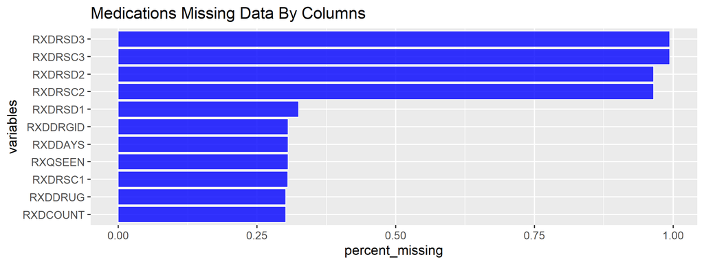

```r
medications_MS <- medications %>% summarise_all(~(sum(is.na(.))/n()))
medications_MS <- gather(medications_MS, key = "variables", value = "percent_missing")
medications_MS <- medications_MS[medications_MS$percent_missing > 0.0, ]
medications_MS_plot <- ggplot(medications_MS, aes(x = reorder(variables, percent_missing),
                                                  y = percent_missing)) +
  geom_bar(stat = "identity", fill = "blue", aes(color = I('white')),
           size = 0.3, alpha = 0.8)+
  xlab('variables')+  coord_flip()+
  #theme_fivethirtyeight() +
  ggtitle("Medications Missing Data By Columns")
#medications_MS_plot
ggsave(plot = medications_MS_plot, width = 8, height = 4, dpi = 300,
       filename = "Figures/medications_MS_plot.png")
```

### 5.1.6 Questionnaire

[figure not shown]

```r
questionnaire_MS <- questionnaire %>% summarise_all(~(sum(is.na(.))/n()))
questionnaire_MS <- gather(questionnaire_MS, key = "variables", value = "percent_missing")
questionnaire_MS <- questionnaire_MS[questionnaire_MS$percent_missing > 0.0, ]
questionnaire_MS_plot <- ggplot(questionnaire_MS, aes(x = reorder(variables, percent_missing),
                                                      y = percent_missing)) +
geom_bar(stat = "identity", fill = "blue", aes(color = I('blue')),
           size = 0.3, alpha = 0.8)+
xlab('variables')+  coord_flip()+
ggtitle("Questionnaire Missing Data By Columns")+
theme(axis.text.y=element_text(size=3))
#questionnaire_MS_plot
ggsave(plot = questionnaire_MS_plot, width = 8, height = 4, dpi = 300,
       filename = "Figures/questionnaire_MS_plot.png")
```

## 5.2 Data Imputation

As per our guidelines, we will select attributes/columns of interest based on our business/personal judgements. The full NHANES data dictionary/variable list is available at the following URL:

https://wwwn.cdc.gov/nchs/nhanes/continuousnhanes/default.aspx?BeginYear=2013

We first remove the variables having near zero variance in the dataset.Later we will remove the variables having more that 25% missing values in the dataset for Demographics.

```r
if (length(nearZeroVar(demographic_major, freqCut = 90/2, uniqueCut = 10, saveMetrics = FALSE,
                       names = FALSE, foreach = FALSE, allowParallel = TRUE)) > 0){
  demographic_major <- demographic_major[, -nearZeroVar(demographic_major, freqCut = 90/2, uniqueCut = 10, saveMetrics = FALSE,
                                                        names = FALSE, foreach = FALSE, allowParallel = TRUE)]

}


# Check the columns for missing values >25%

sapply(demographic_major, function(x) ((sum(is.na(x))))*.01) %>%
  stack %>% rev %>% filter(values > 25) %>% setNames(nm=c("variable", "missing"))


Null_Num <- apply(demographic_major, 2, function(x) length(which(is.na(x) | x == "NA"))/length(x))
Null_Colms <- colnames(demographic_major)[Null_Num > 0.25]
demographic75 <- select(demographic_major, -Null_Colms)
```

We will now refer to our Dictionary for making a reference dataframe to differentiate between different forms of variables in a fast and effective way:

```r
demographic_indexed <- demographic75
colnames(demographic_indexed) <- with(Dictionary,
                                      Dictionary$Variable.Description[match(colnames(demographic75),
                                                                            Dictionary$Variable.Name,
                                                                            nomatch = Dictionary$Variable.Name
                                      )])

Demogramphic_Col_Labels <- data.frame("Code"=c(colnames(demographic75)),
                                      "Desp"=c(colnames(demographic_indexed)))
```

Categorization of variables

We have to now enter categorization of Factor/Numeric/ ‘Computation not required’ in the excel file generated  
* Only to be done in 3rd column…  
* Code is….  
* **0** = Factor requiring no computation.  
* **1** = Numeric requiring computation.  
* **2** = Factor requiring computation.  
* **Please write Column name for the category as “Cat”**  
Reading Index again

```r
Cat_demo <- c(0,2,2,2,2,2,2,2,2,2,2,2,2,2,2,2,2,2,2,2,2,2,2,2,1,1,1,1,1,1,1)
Demogramphic_Col_Labels <- data.frame(Demogramphic_Col_Labels,Cat = Cat_demo)
```

Now we prepare the dataset for impute from all the information.

```r
Catcolmn <- Demogramphic_Col_Labels[Demogramphic_Col_Labels$Cat ==2 , 2 ]
Numcolmn <- Demogramphic_Col_Labels[Demogramphic_Col_Labels$Cat ==1 , 2 ]
Catcolmn_Nul <- Demogramphic_Col_Labels[Demogramphic_Col_Labels$Cat ==0 , 2 ]
WorkingColm <- c(Catcolmn_Nul, Numcolmn, Catcolmn)
WorkingColm
)
demographic_selected = demographic75[ Catcolmn_Nul ]

demographic_selected = demographic75[ WorkingColm ]

demographic_selected[, Catcolmn] <- sapply(demographic_selected[, Catcolmn], as.numeric)
demographic_selected[, Catcolmn_Nul] <- sapply(demographic_selected[, Catcolmn_Nul], as.numeric)
demographic_selected[, Numcolmn] <- sapply(demographic_selected[, Numcolmn], as.numeric)
```

- ========================== IMPUTATION( MICE package) =======================
- Precisely, the methods used by this package are:
- 1)-PMM (Predictive Mean Matching) For numeric variables
- 2)-logreg(Logistic Regression) For Binary Variables( with 2 levels)
- 3)-polyreg(Bayesian polytomous regression) For Factor Variables (>= 2 levels)
- 4)-Proportional odds model (ordered, >= 2 levels)
- 5)-cart Classification and regression trees (any)
- 6)rf Random forest imputations (any)
- ==============================================================================  
  Imputation and save results:

```r
meth = init$method
predM = init$predictorMatrix
predM[, c("SEQN")]=0
meth[Catcolmn_Nul] = ""
meth[Catcolmn]="cart"
meth[Numcolmn]="rf"
set.seed(103)
imputed = mice(demographic_selected, method=meth, predictorMatrix=predM, m=5)

#Create a dataset after imputation.

demographic_imputed<- complete(imputed)
rm(Demogramphic_Col_Labels,demographic75,demographic_selected, imputed)

dir.create("Data/Clean_Imputes")
#write.csv(demographic_imputed , "Data/Clean_Imputes/demographic_imputed.csv",row.names = FALSE)
demographic_imputed   = read.csv("Data/Clean_Imputes/demographic_imputed.csv", header = TRUE, na.strings = c("NA","","#NA"))
```

### 5.2.1 Demographic

Now we will label the dataset for visualizations.

```r
multi.hist(demo_subset_8_imputed[,sapply(demo_subset_8_imputed, is.numeric)])

demo_subset_8<- demo_subset_8 %>%
  rename("ID"                 =         "SEQN",
         "Gender"             =     "RIAGENDR",
         "Age"                =     "RIDAGEYR",
         "Race"               =     "RIDRETH3",
         "Country_of_birth"   =     "DMDBORN4",
         "Citizenship_status" =     "DMDCITZN",
         "Family_members"     =     "DMDFMSIZ",
         "Marital_status"     =     "DMDHRMAR",
         "Family_income"      =     "INDFMIN2"  )

sapply(demo_subset_8, function(x) sum(is.na(x)))
```

```r
require(dplyr)# because Race is a factor of level 6
demo_subset_8_labeled <- demo_subset_8_labeled %>%
  mutate(Race = recode(Race, "1" = "Mexican_American",
                       "2" = "Other_Hispanic",
                       "3" = "White",
                       "4" = "Black",
                       "6" = "Asian",
                       "7" = "multiracial"))
demo_subset_8_labeled <- demo_subset_8_labeled %>%
  mutate(Country_of_birth  = recode(Country_of_birth , "1" = "US",
                       "2" = "Others",
                       "77" = "Refused",
                       "99" = "Uknown"))
demo_subset_8_labeled <- demo_subset_8_labeled %>%
  mutate(Citizenship_status = recode(Citizenship_status, "1" = "US",
                       "2" = "Other",
                       "7" = "Refused",
                       "9" = "Unknown"))
demo_subset_8_labeled <- demo_subset_8_labeled %>%
  mutate(Marital_status = recode(Marital_status, "1" = "Married",
                       "2" = "Widowed",
                       "3" = "Divorced",
                       "4" = "Separated",
                       "5" = "Never_married",
                       "6" = "partner",
                       "77" = "Refused",
                       "99" = "Unknown"))
demo_subset_8_labeled <- demo_subset_8_labeled %>%
  mutate(Family_income = recode(Family_income, "1" =    "$0 - $4999",
                                "2" =   "$5000 - $9999",
                                "3" =   "$10000 - $14999",
                                "4" =   "$15000 - $19999",
                                "5" =   "$20000 - $24999",
                                "6" =   "$25000 - $34999",
                                "7" =   "$35000 - $44999",
                                "8" =   "$45000 - $54999",
                                "9" =   "$55000 - $64999",
                                "10" =  "$65000 - $74999",
                                "12" =  "$20000 and Over",
                                "13" =  "Under $20000",
                                "14" =  "$75000 - $99999",
                                "15" = "$100000 and Over",
                                "77" =  "Refused",
                                "99" =  "Unknown"   ))
demo_subset_8_imputed$Family_income <- as.factor(demo_subset_8_imputed$Family_income)
#write.csv(demo_subset_8_labeled,file = "Data/Working/demo_subset_8_labeled.csv")
```

#### 5.2.1.1 Gender

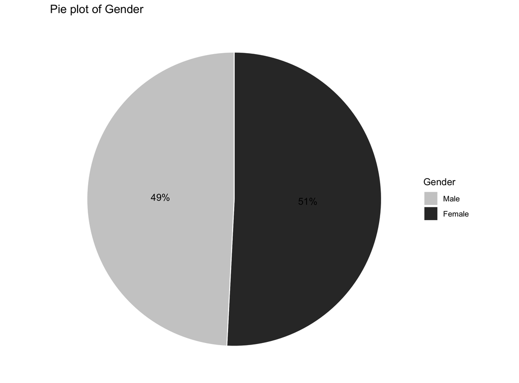

```r
##########################  Gender #############
Gender  <- demo_subset_8_labeled %>%
  group_by(Gender) %>%
  summarize(count=n()) %>%
  arrange(desc(count))
#Pie plot
Gender_plot <- ggplot(Gender, aes(x = "", y =  round(100*count/sum(count), 1),
                                  fill =  reorder(Gender,count))) +
  geom_bar(width = 1, stat = "identity", color = "white") +
  coord_polar("y", start = 0)+
  geom_text(aes(y = cumsum(100*count/sum(count)) - 0.5*(100*count/sum(count)),
                label = paste(round(count/sum(count)*100),"%")), color = "black")+
  ggtitle("Pie plot of Gender")+
  scale_fill_grey(start = 0.8, end = 0.2,"Gender") + theme_void()
#ggsave(plot = Gender_plot, width = 3, height = 3, dpi = 300,
#       filename = "Figures/Gender_plot.png")
```

#### 5.2.1.2 Country of birth

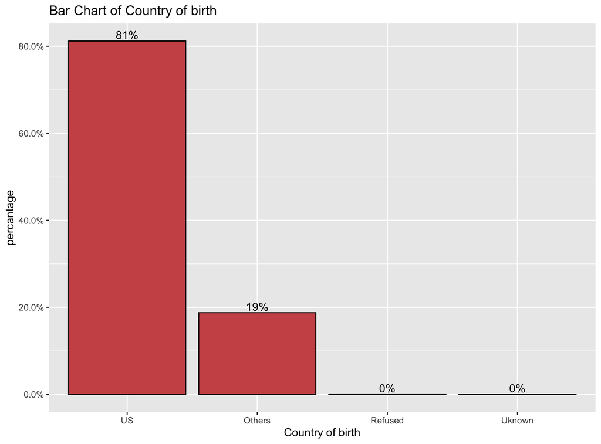

```r
##########################  Country_of_birth #############
Country_of_birth  <- demo_subset_8_labeled %>%
  group_by(Country_of_birth) %>%
  summarize(count=n()) %>%
  arrange(desc(count))%>%
  mutate(pct = count / sum(count),
         pctlabel = paste0(round(pct*100), "%"),
         lab.ypos = 100*cumsum(pct) - 0.5  *100*pct)
#Bar plot
require(scales)
Birth_plot <- ggplot(Country_of_birth, aes(x = reorder(Country_of_birth, -pct),y = pct)) +
  geom_bar(stat = "identity", fill = "indianred3", color = "black") +
  geom_text(aes(label = pctlabel), vjust = -0.25) +
  scale_y_continuous(labels = percent) +
  labs(x = "Country of birth", y = "percantage", title  = "Bar Chart of Country of birth")
#ggsave(plot = Birth_plot, width = 3, height = 3, dpi = 300,
 #      filename = "Figures/Birth_plot.png")
```

#### 5.2.1.3 Marital status

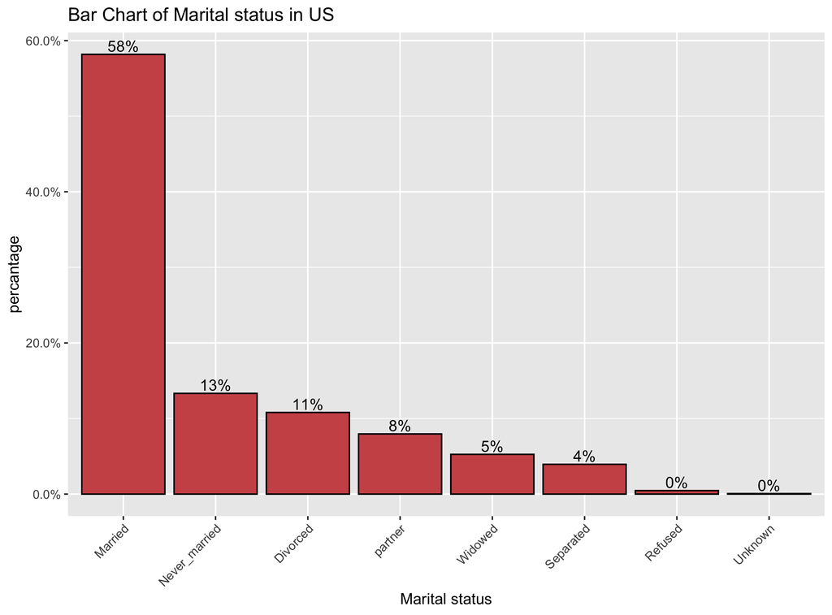

```r
########################  Marital_status  #######################
Marital_status  <- demo_subset_8_labeled %>%
  group_by(Marital_status) %>%
  summarize(count=n()) %>%
  arrange(desc(count))%>%
  mutate(pct = count / sum(count),
         pctlabel = paste0(round(pct*100), "%"),
         lab.ypos = 100*cumsum(pct) - 0.5  *100*pct)
#Bar plot
require(scales)
Marital_plot <- ggplot(Marital_status, aes(x = reorder(Marital_status, -pct),y = pct)) +
  geom_bar(stat = "identity", fill = "indianred3", color = "black") +
  geom_text(aes(label = pctlabel), vjust = -0.25) +
  scale_y_continuous(labels = percent) +
  labs(x = "Marital statush", y = "percantage", title  = "Bar Chart of Marital status in US ")  +
  theme(axis.text.x = element_text(angle = 45, hjust = 1))
#ggsave(plot = Marital_plot, width = 3, height = 3, dpi = 300,
#       filename = "Figures/Marital_plot.png")
```

#### 5.2.1.4 Race

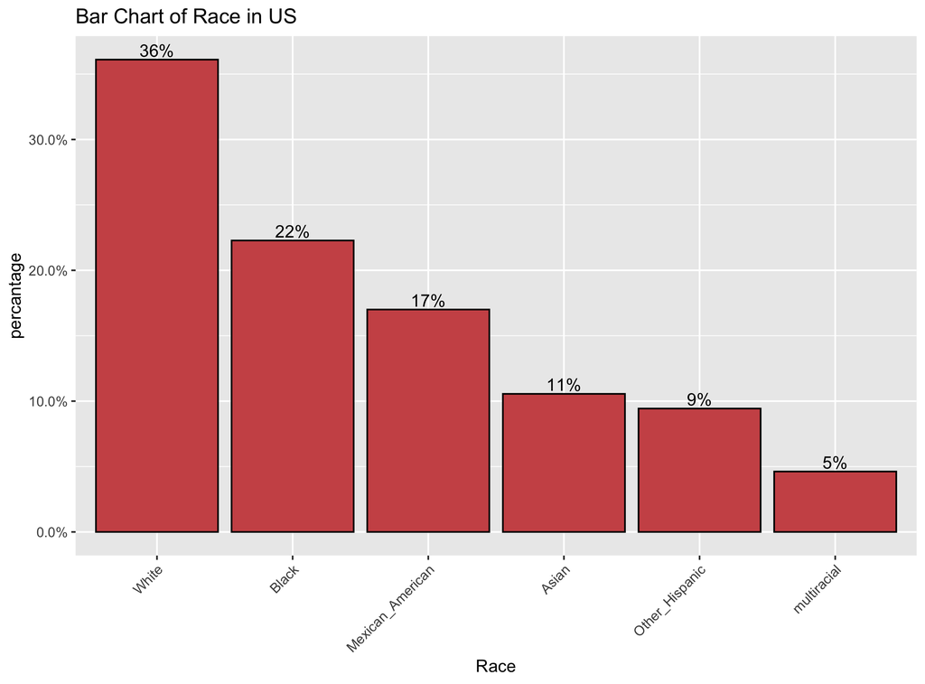

```r
########################  Race  #######################
Race  <- demo_subset_8_labeled %>%
  group_by(Race) %>%
  summarize(count=n()) %>%
  arrange(desc(count))%>%
  mutate(pct = count / sum(count),
         pctlabel = paste0(round(pct*100), "%"),
         lab.ypos = 100*cumsum(pct) - 0.5  *100*pct)
#Bar plot
require(scales)
Race_plot <- ggplot(Race, aes(x = reorder(Race, -pct),y = pct)) +
  geom_bar(stat = "identity", fill = "indianred3", color = "black") +
  geom_text(aes(label = pctlabel), vjust = -0.25) +
  scale_y_continuous(labels = percent) +
  labs(x = "Race", y = "percantage", title  = "Bar Chart of Race in US ")  +
  theme(axis.text.x = element_text(angle = 45, hjust = 1))
#ggsave(plot = Race_plot, width = 3, height = 3, dpi = 300,
#       filename = "Figures/Race_plot.png")
```

#### 5.2.1.5 Conclusion

- The US age structure is 20% under 15, 67% between 15 and 64 years old, and 13% over 65 (https://countrymeters.info/en/United_States_of_America_(USA)).
- The Gender ratio is 51% for female and 49% for male (http://statisticstimes.com/demographics/countries-by-sex-ratio.php)
- The Race and ethnicity are: White 72.4%, Hispanic and Latino Americans 16.3%, Black or African American 12.6%, Asian 4.8%, Native 1.1 %, and the others 9.1 %.

### 5.2.2 Diet

First we would remove all the Near Zero Variance features from the data set, Cutt off being 45% :

```r
diet_major <- diet

if (length(nearZeroVar(diet_major, freqCut = 90/2, uniqueCut = 10, saveMetrics = FALSE,
                       names = FALSE, foreach = FALSE, allowParallel = TRUE)) > 0){
  diet_major <- diet_major[, -nearZeroVar(diet_major, freqCut = 90/2, uniqueCut = 10, saveMetrics = FALSE,
                                          names = FALSE, foreach = FALSE, allowParallel = TRUE)]

}
```

Now, we will remove the features having a missing values of more that 25% as decided before:

```r
Null_Num_diet <- apply(diet_major, 2, function(x) length(which(x == "" | is.na(x) | x == "NA" | x == "-999" ))/length(x))
Null_Colms_diet <- colnames(diet_major)[Null_Num_diet > 0.25]
diet75 <- select(diet_major, -Null_Colms_diet)

colSums(is.na(diet75))
diet75 %>% summarise_all(~(sum(is.na(.))/n()*100))
```

We have selected the following 69 relevant columns among the 88 that have less than 25% of missing values:

- **ID (SEQN)** - Respondent sequence number.
- **Number_of_foods (DR1TNUMF)** - Total number of foods/beverages reported in the individual foods file.
- **Energy_kcal (DR1TKCAL)** - Energy (kcal).
- **Protein (DR1TPROT)** - Protein (gm).
- **Carbohydrate (DR1TCARB)** - Carbohydrate (gm).
- **Sugar (DR1TSUGR)** - Total sugars (gm).
- **Fiber (DR1TFIBE)** - Dietary fiber (gm).
- **Total_fat (DR1TTFAT)** - Total fat (gm).
- **Sat_fats (DR1TSFAT)** - Total saturated fatty acids (gm).
- **Mono_fats (DR1TMFAT)** - Total monounsaturated fatty acids (gm).
- **Poly_fats (DR1TPFAT)** - Total polyunsaturated fatty acids (gm).
- **Cholesterol (DR1TCHOL)** - Cholesterol (mg).
- **Tocopherol (DR1TATOC)** - Vitamin E as alpha-tocopherol (mg).
- **Tocopherol_alpha (DR1TATOA)** - Added alpha-tocopherol (Vitamin E) (mg).
- **Retinol (DR1TRET)** - Retinol (mcg).
- **Retinol_a (DR1TVARA)** - Vitamin A as retinol activity equivalents (mcg).
- **Carotene_alpha (DR1TACAR)** - Alpha-carotene (mcg).
- **Carotene_beta (DR1TBCAR)** - Beta-carotene (mcg).
- **Cryptoxanthin (DR1TCRYP)** - Beta-cryptoxanthin (mcg).
- **Lycopene (DR1TLYCO)** - Lycopene (mcg).
- **Lutein_zeaxanthin (DR1TLZ)** - Lutein + zeaxanthin (mcg).
- **Thiamin (DR1TVB1)** - Thiamin (Vitamin B1) (mg).
- **Riboflavin (DR1TVB2)** - Riboflavin (Vitamin B2) (mg).
- **Niacin (DR1TNIAC)** - Niacin (mg).
- **Vitamin_b6 (DR1TVB6)** - Vitamin B6 (mg).
- **Folate (DR1TFOLA)** - Total folate (mcg).
- **Folic_acid (DR1TFA)** - Folic acid (mcg).
- **Folate_food (DR1TFF)** - Food folate (mcg).
- **Folate_equivs (DR1TFDFE)** - Folate as dietary folate equivalents (mcg).
- **Choline (DR1TCHL)** - Total choline (mg).
- **Vitamine_b12 (DR1TVB12)** - Vitamin B12 (mcg).
- **Vitamine_b12_added (DR1TB12A)** - Added vitamin B12 (mcg).
- **Vitamine_c (DR1TVC)** - Vitamin C (mg).
- **Vitamine_d (DR1TVD)** - Vitamin D (D2 + D3) (mcg).
- **Vitamine_k (DR1TVK)** - Vitamin K (mcg).
- **Calcium (DR1TCALC)** - Calcium (mg).
- **Phosphorus (DR1TPHOS)** - Phosphorus (mg).
- **Magnesium (DR1TMAGN)** - Magnesium (mg).
- **Iron (DR1TIRON)** - Iron (mg).
- **Zinc (DR1TZINC)** - Zinc (mg).
- **Copper (DR1TCOPP)** - Copper (mg).
- **Sodium (DR1TSODI)** - Sodium (mg).
- **Potassium (DR1TPOTA)** - Potassium (mg).
- **Selenium (DR1TSELE)** - Selenium (mcg).
- **Caffeine (DR1TCAFF)** - Caffeine (mg).
- **Theobromine (DR1TTHEO)** - Theobromine (mg).
- **Alcohol (DR1TALCO)** - Alcohol (gm).
- **Moisture (DR1TMOIS)** - Moisture (gm).
- **Butanoic (DR1TS040)** - SFA 4:0 (Butanoic) (gm).
- **Hexanoic (DR1TS060)** - SFA 6:0 (Hexanoic) (gm).
- **Octanoic (DR1TS080)** - SFA 8:0 (Octanoic) (gm).
- **Decanoic (DR1TS100)** - SFA 10:0 (Decanoic) (gm).
- **Dodecanoic (DR1TS120)** - SFA 12:0 (Dodecanoic) (gm).
- **Tetradecanoic (DR1TS140)** - SFA 14:0 (Tetradecanoic) (gm).
- **Hexadecanoic (DR1TS160)** - SFA 16:0 (Hexadecanoic) (gm).
- **Octadecanoic (DR1TS180)** - SFA 18:0 (Octadecanoic) (gm).
- **Hexadecenoic (DR1TM161)** - MFA 16:1 (Hexadecenoic) (gm).
- **Octadecenoic (DR1TM181)** - MFA 18:1 (Octadecenoic) (gm).
- **Eicosenoic (DR1TM201)** - MFA 20:1 (Eicosenoic) (gm).
- **Docosenoic (DR1TM221)** - MFA 22:1 (Docosenoic) (gm).
- **Octadecadienoic (DR1TP182)** - PFA 18:2 (Octadecadienoic) (gm).
- **Octadecatrienoic (DR1TP183)** - PFA 18:3 (Octadecatrienoic) (gm).
- **Octadecatetraenoic (DR1TP184)** - PFA 18:4 (Octadecatetraenoic) (gm).
- **Eicosapentaenoic (DR1TP204)** - PFA 20:4 (Eicosatetraenoic) (gm).
- **Eicosapentaenoic (DR1TP205)** - PFA 20:5 (Eicosapentaenoic) (gm).
- **Docosapentaenoic (DR1TP225)** - PFA 22:5 (Docosapentaenoic) (gm).
- **Docosahexaenoic (DR1TP226)** - PFA 22:6 (Docosahexaenoic) (gm).
- **Food_yesterday (DR1_300)** - Was the amount of food that {you/NAME} ate yesterday much more than usual, usual, or much less than usual?.
- **Water_yesterday (DR1_320Z)** - Total plain water drank yesterday - including plain tap water, water from a drinking fountain, water from a water cooler, bottled water, and spring water..

We will now refer to our Dictionary for making a reference dataframe to differentiate between different forms of variables in a fast and effective way:

```r
diet_indexed <- diet75
colnames(diet_indexed) <- with(Dictionary,
                               Dictionary$Variable.Description[match(colnames(diet75),
                                                                     Dictionary$Variable.Name,
                                                                     nomatch = Dictionary$Variable.Name
                               )])

diet_Col_Labels <- data.frame("Code"=c(colnames(diet75)),
                              "Desp"=c(colnames(diet_indexed)))
```

Categorization of variables

We have to now enter categorization of Factor/Numeric/ ‘Computation not required’ in the excel file generated  
* Only to be done in 3rd column…  
* Code is….  
* **0** = Factor requiring no computation.  
* **1** = Numeric requiring computation.  
* **2** = Factor requiring computation.  
* **Please write Column name for the category as “Cat”**  
Reading Index again

```r
Cat_diet <- c(0,1,1,2,2,2,1,2,2,2,2,2,2,2,2,1,1,1,1,1,1,1,1,1,1,1,1,1,1,1,1,1,1,1,1,
              1,1,1,1,1,1,1,1,1,1,1,1,1,1,1,1,1,1,1,1,1,1,1,1,1,1,1,1,1,1,1,1,1,1,1,
              1,1,1,1,1,1,1,1,1,1,1,1,2,2,2)
diet_Col_Labels <- data.frame(diet_Col_Labels,Cat = Cat_diet)

diet_Col_Labels   = read.csv("Data/Labels/diet_Col_Labels.csv", header = TRUE, na.strings = c("NA","","#NA"))

diet_Col_Labels[, 2] <- sapply(diet_Col_Labels[, 2], as.character)
```

Now we prepare the dataset for impute from all the information.

```r
Catcolmn_diet <- diet_Col_Labels[diet_Col_Labels$Cat ==2 , 2 ]
Numcolmn_diet <- diet_Col_Labels[diet_Col_Labels$Cat ==1 , 2 ]
Catcolmn_Nul_diet <- diet_Col_Labels[diet_Col_Labels$Cat ==0 , 2 ]
WorkingColm_diet <- c(Catcolmn_Nul_diet, Numcolmn_diet, Catcolmn_diet)
```

- ========================== IMPUTATION( MICE package) =======================
- Precisely, the methods used by this package are:
- 1)-PMM (Predictive Mean Matching) For numeric variables
- 2)-logreg(Logistic Regression) For Binary Variables( with 2 levels)
- 3)-polyreg(Bayesian polytomous regression) For Factor Variables (>= 2 levels)
- 4)-Proportional odds model (ordered, >= 2 levels)
- 5)-cart Classification and regression trees (any)
- 6)rf Random forest imputations (any)
- ==============================================================================

```r
meth_diet = init_diet$method
predM_diet = init_diet$predictorMatrix
predM_diet[, c("SEQN")]=0
meth_diet[Catcolmn_Nul_diet] = ""
meth_diet[Catcolmn_diet]="cart"
meth_diet[Numcolmn_diet]="pmm"
set.seed(256)
imputed_diet = mice(diet_selected, method=meth_diet, predictorMatrix=predM_diet, m=5)

#Create a dataset after imputation.

diet_imputed<- complete(imputed_diet)

#######################################  Saving Impute

#write.csv(diet_imputed , "Data/Clean_Imputes/diet_imputed.csv",row.names = FALSE)
diet_imputed   = read.csv("Data/Clean_Imputes/diet_imputed.csv", header = TRUE, na.strings = c("NA","","#NA"))
```

Labeling the dataset:

```r
diet_labeled <- diet_imputed
rm(diet_imputed)

diet_labeled <- diet_labeled %>%
  dplyr::rename("ID"                =         "SEQN",
                "Carbs_diet"        =     "DR1TCARB",
                "Sugar_diet"        =     "DR1TSUGR",
                "Fiber_diet"        =     "DR1TFIBE",
                "transfat_diet"     =     "DR1TTFAT",
                "satfat_diet"       =     "DR1TSFAT",
                "zinc_diet"         =     "DR1TZINC",
                "copper_diet"       =     "DR1TCOPP",
                "sodium_diet"       =     "DR1TSODI",
                "pota_diet"         =     "DR1TPOTA",
                "selenium_diet"     =     "DR1TSELE"  )
```

### 5.2.3 Examination

First we would remove all the Near Zero Variance features from the data set, Cutt off being 45% :

```r
exam_major <- examination
rm(examination)

if (length(nearZeroVar(exam_major, freqCut = 90/2, uniqueCut = 10, saveMetrics = FALSE,
                       names = FALSE, foreach = FALSE, allowParallel = TRUE)) > 0){
  exam_major <- exam_major[, -nearZeroVar(exam_major, freqCut = 90/2, uniqueCut = 10, saveMetrics = FALSE,
                                          names = FALSE, foreach = FALSE, allowParallel = TRUE)]

}
```

Now, we will remove the features having a missing values of more that 25% as decided before:

```r
Null_Num_diet <- apply(diet_major, 2, function(x) length(which(x == "" | is.na(x) | x == "NA" | x == "-999" ))/length(x))
Null_Colms_diet <- colnames(diet_major)[Null_Num_diet > 0.25]
diet75 <- select(diet_major, -Null_Colms_diet)

colSums(is.na(diet75))
diet75 %>% summarise_all(~(sum(is.na(.))/n()*100))
```

We will now refer to our Dictionary for making a reference dataframe to differentiate between different forms of variables in a fast and effective way:

```r
exam_indexed <- exam75
colnames(exam_indexed) <- with(Dictionary,
                               Dictionary$Variable.Description[match(colnames(exam75),
                                                                     Dictionary$Variable.Name,
                                                                     nomatch = Dictionary$Variable.Name
                               )])

exam_Col_Labels <- data.frame("Code"=c(colnames(exam75)),
                              "Desp"=c(colnames(exam_indexed)))
```

Categorization of variables

We have to now enter categorization of Factor/Numeric/ ‘Computation not required’ in the excel file generated  
* Only to be done in 3rd column…  
* Code is….  
* **0** = Factor requiring no computation.  
* **1** = Numeric requiring computation.  
* **2** = Factor requiring computation.  
* **Please write Column name for the category as “Cat”**  
Reading Index again

```r
Cat_exam <- c(0,1,1,1,1,1,1,1,1,1,1,1,1,1,1,1,1,1,1,1,1,1,1,1,1,1,1,1,1,
              1,1,1,1,1,1,1,1,1,1,1,1,1,1,1,1,1,1,1,1,1,1,1,1,1,1,1,1,1,
              1,1,1,1,1,1,1,1,1,1,1,1,1,1,1,1,1,1,1,1,1,1,1,1,1,1,1,1,1,
              1,1,1,1,1,1,1,1,1,1)
exam_Col_Labels <- data.frame(exam_Col_Labels,Cat = Cat_exam)
```

Now we prepare the dataset for impute from all the information.

```r
Catcolmn_exam <- exam_Col_Labels[exam_Col_Labels$Cat ==2 , 2 ]
Numcolmn_exam <- exam_Col_Labels[exam_Col_Labels$Cat ==1 , 2 ]
Catcolmn_Nul_exam <- exam_Col_Labels[exam_Col_Labels$Cat ==0 , 2 ]
WorkingColm_exam <- c(Catcolmn_Nul_exam, Numcolmn_exam, Catcolmn_exam)
```

- ========================== IMPUTATION( MICE package) =======================
- Precisely, the methods used by this package are:
- 1)-PMM (Predictive Mean Matching) For numeric variables
- 2)-logreg(Logistic Regression) For Binary Variables( with 2 levels)
- 3)-polyreg(Bayesian polytomous regression) For Factor Variables (>= 2 levels)
- 4)-Proportional odds model (ordered, >= 2 levels)
- 5)-cart Classification and regression trees (any)
- 6)rf Random forest imputations (any)
- ==============================================================================

```r
meth_exam = init_exam$method
predM_exam = init_exam$predictorMatrix
predM_exam[, c("SEQN")]=0
meth_exam[Catcolmn_Nul_exam] = ""
meth_exam[Catcolmn_exam]="cart"
meth_exam[Numcolmn_exam]="pmm"

set.seed(311)
imputed_exam = mice(exam_selected, method=meth_exam, predictorMatrix=predM_exam, m=5)

#Create a dataset after imputation.

exam_imputed<- complete(imputed_exam)
rm(imputed_exam)

#######################################  Saving Impute


#write.csv(exam_imputed , "Data/Clean_Imputes/exam_imputed.csv",row.names = FALSE)
exam_imputed   = read.csv("Data/Clean_Imputes/exam_imputed.csv", header = TRUE, na.strings = c("NA","","#NA"))
```

Labeling the dataset:

```r
exam_labeled <- exam_imputed
rm(exam_imputed)

exam_labeled = dplyr::rename(
  exam_labeled,
  "ID"                  = "SEQN",
  "BP_test_time_exam"        = "PEASCTM1",
  "BP_arm_exam"              = "BPAARM",
  "BP_Systolic_exam"         = "BPXSY2",
  "BP_Diastolic_exam"        = "BPXDI2",
  "Weight_exam"              = "BMXWT",
  "Height_exam"              = "BMXHT",
  "Leg_length_exam"          = "BMXBMI",
  "Arm_length_exam"          = "BMXLEG",
  "Waist_circumference_exam" = "BMXWAIST",
  "Dominant_hand_exam"       = "MGD130",
  "Grip_strength_exam"       = "MGDCGSZ"
)

exam_labeled = mutate(
  exam_labeled,
  BP_arm_exam = recode(BP_arm_exam,
                       "1" = "Left",
                       "2" = "Right"),
  Dominant_hand_exam = recode(Dominant_hand_exam,
                              "1"="Right",
                              "2"="Left",
                              "3"="Neither")
)

exam_labeled[ , 70:97]  <- lapply(exam_labeled[ ,70:97] , FUN = function(x) recode(x, "1='D';2='E';3='J';4='K';5='M';6='P';7='Q';8='R';9='S';10='T';11='U';12='X';13='Y';14='Z'"))
```

### 5.2.4 Labs

First we would remove all the Near Zero Variance features from the data set, Cutt off being 45% :

```r
labsdata_major <- labs

if (length(nearZeroVar(labsdata_major, freqCut = 90/2, uniqueCut = 10, saveMetrics = FALSE,
                       names = FALSE, foreach = FALSE, allowParallel = TRUE)) > 0){
  labsdata_major <- labsdata_major[, -nearZeroVar(labsdata_major, freqCut = 90/2, uniqueCut = 10, saveMetrics = FALSE,
                                                  names = FALSE, foreach = FALSE, allowParallel = TRUE)]

}
```

```r
Null_Num_labsdata <- apply(labsdata_major, 2, function(x) length(which(x == "" | is.na(x) | x == "NA" | x == "-999" ))/length(x))
Null_Colms_labsdata <- colnames(labsdata_major)[Null_Num_labsdata > 0.35]
labsdata75 <- select(labsdata_major, -Null_Colms_labsdata)
```

- **ID (SEQN)** - Respondent sequence number..
- **White_blood_cells_labs (LBXWBCSI)** - White blood cell count (1000 cells/uL).
- **Red_bloods_cells_labs (LBXRBCSI)** - Red blood cell count (million cells/uL).
- **Caffeine_labs (PHQ020)** - Coffee or tea with cream or sugar? [Include milk or non-dairy creamers.].
- **Alcohol_labs (PHQ030)** - Alcohol, such as beer, wine, or liquor?.
- **Supplements_labs (PHQ060)** - Dietary supplements such as vitamins and minerals? [Include multivitamins and single nutrient supplements.].
- **Hepatitis_a_labs (LBXHA)** - Hepatitis A antibody.
- **Hepatitis_b_labs (LBXHBC)** - Hepatitis B core antibody.
- **Cholesterol_labs (LBXTC)** - Total Cholesterol( mg/dL).

We will now refer to our Dictionary for making a reference dataframe to differentiate between different forms of variables in a fast and effective way:

```r
labsdata_indexed <- labsdata75
colnames(labsdata_indexed) <- with(Dictionary,
                                   Dictionary$Variable.Description[match(colnames(labsdata75),
                                                                         Dictionary$Variable.Name,
                                                                         nomatch = Dictionary$Variable.Name
                                   )])

labsdata_Col_Labels <- data.frame("Code"=c(colnames(labsdata75)),
                                  "Desp"=c(colnames(labsdata_indexed)))
```

Categorization of variables

We have to now enter categorization of Factor/Numeric/ ‘Computation not required’ in the excel file generated  
* Only to be done in 3rd column…  
* Code is….  
* **0** = Factor requiring no computation.  
* **1** = Numeric requiring computation.  
* **2** = Factor requiring computation.  
* **Please write Column name for the category as “Cat”**  
Reading Index again

```r
Cat_labs <- c(0,1,1,2,1,1,1,1,1,1,1,1,1,1,1,1,1,1,1,1,1,
              1,1,1,1,1,1,1,1,1,1,1,1,1,1,1,1,1,1,1,1,1,
              1,1,1,1,1,1,1,1,1,1,1,1,1,1,1,1,1,1,1,1,1,
              2,2,2,2,1,1,2,2,2,2,1,1,1,1,1)
labsdata_Col_Labels <- data.frame(labsdata_Col_Labels,Cat = Cat_labs)
```

Now we prepare the dataset for impute from all the information.

```r
Catcolmn_labsdata <- labsdata_Col_Labels[labsdata_Col_Labels$Cat ==2 , 2 ]
Numcolmn_labsdata <- labsdata_Col_Labels[labsdata_Col_Labels$Cat ==1 , 2 ]
Catcolmn_Nul_labsdata <- labsdata_Col_Labels[labsdata_Col_Labels$Cat ==0 , 2 ]
WorkingColm_labsdata <- c(Catcolmn_Nul_labsdata, Numcolmn_labsdata, Catcolmn_labsdata)
```

- ========================== IMPUTATION( MICE package) =======================
- Precisely, the methods used by this package are:
- 1)-PMM (Predictive Mean Matching) For numeric variables
- 2)-logreg(Logistic Regression) For Binary Variables( with 2 levels)
- 3)-polyreg(Bayesian polytomous regression) For Factor Variables (>= 2 levels)
- 4)-Proportional odds model (ordered, >= 2 levels)
- 5)-cart Classification and regression trees (any)
- 6)rf Random forest imputations (any)
- ==============================================================================

```r
meth_labsdata = init_labsdata$method
predM_labsdata = init_labsdata$predictorMatrix
predM_labsdata[, c("SEQN")]=0
meth_labsdata[Catcolmn_Nul_labsdata] = ""
meth_labsdata[Catcolmn_labsdata]="cart"
meth_labsdata[Numcolmn_labsdata]="pmm"
set.seed(415)
imputed_labsdata = mice(labsdata_selected, method=meth_labsdata, predictorMatrix=predM_labsdata, m=5)
labsdata_imputed<- complete(imputed_labsdata)

rm(imputed_labsdata)

#Check for missings in the imputed dataset.
sapply(labsdata_imputed, function(x) sum(is.na(x)))

#######################################  Saving Impute

#write.csv(labsdata_imputed , "Data/Clean_Imputes/labsdata_imputed.csv",row.names = FALSE)
labsdata_imputed   = read.csv("Data/Clean_Imputes/labsdata_imputed.csv", header = TRUE, na.strings = c("NA","","#NA"))
```

Labeling the dataset:

```r
labs_labeled <- labs_labeled %>%
  dplyr::rename("ID"                =         "SEQN",
                "White_blood_cells_labs" =     "LBXWBCSI",
                "Red_bloods_cells_labs"  =     "LBXRBCSI",
                "Caffeine_labs"          =     "PHQ020",
                "Alcohol_labs"           =     "PHQ030",
                "Supplements_labs"       =     "PHQ060",
                "Hepatitis_a_labs"       =     "LBXHA",
                "Hepatitis_b_labs"       =     "LBXHBC",
                "Cholesterol_labs"       =     "LBXTC"  )


labs_labeled = labs_labeled %>%
  mutate(Caffeine_labs= recode(Caffeine_labs, "1" = "Yes",
                               "2" = "No",
                               "NA" = "Not Tested"))


labs_labeled = labs_labeled %>%
  mutate(Alcohol_labs= recode(Alcohol_labs, "1" = "Yes",
                              "2" = "No",
                              "NA" = "Not Tested"))

labs_labeled = labs_labeled %>%
  mutate(Supplements_labs= recode(Supplements_labs, "1" = "Yes",
                                  "2" = "No",
                                  "NA" = "Not Tested"))



labs_labeled = labs_labeled %>%
  mutate(Hepatitis_a_labs= recode(Hepatitis_a_labs, "1" = "Positive",
                                  "2" = "Negative",
                                  "3" = "Indeterminate",
                                  "NA" = "Not Tested"))


labs_labeled = labs_labeled %>%
  mutate(Hepatitis_b_labs= recode(Hepatitis_b_labs, "1" = "Positive",
                                  "2" = "Negative",
                                  "NA" = "Not Tested"))
```

### 5.2.5 Medication

First we would remove all the Near Zero Variance features from the data set, Cutt off being 45% :

```r
medsdata_major <- medications
if (length(nearZeroVar(medsdata_major, freqCut = 90/2, uniqueCut = 10, saveMetrics = FALSE,
                       names = FALSE, foreach = FALSE, allowParallel = TRUE)) > 0){
  medsdata_major <- medsdata_major[, -nearZeroVar(medsdata_major, freqCut = 90/2, uniqueCut = 10, saveMetrics = FALSE,
                                                  names = FALSE, foreach = FALSE, allowParallel = TRUE)]

}
```

```r
Null_Num_medsdata <- apply(medsdata_major, 2, function(x) length(which(x == "" | is.na(x) | x == "NA" | x == "-999" ))/length(x))
Null_Colms_medsdata <- colnames(medsdata_major)[Null_Num_medsdata > 0.33]
medsdata68 <- select(medsdata_major, -Null_Colms_medsdata)
```

- **ID (SEQN)** - Respondent sequence number.
- **Medication (RXDDRGID)** - Generic drug name.
- **Days_taken (RXDDAYS)** - Number of days taken medicine.
- **Medication_purpose (RXDRSD1)** - Reasons for use reported by participants.
- **Amount_taken (RXDCOUNT)** - Number of prescription medicines taken.

We will now refer to our Dictionary for making a reference dataframe to differentiate between different forms of variables in a fast and effective way:

```r
medsdata_indexed <- medsdata68
colnames(medsdata_indexed) <- with(Dictionary,
                                   Dictionary$Variable.Description[match(colnames(medsdata68),
                                                                         Dictionary$Variable.Name,
                                                                         nomatch = Dictionary$Variable.Name
                                   )])
medsdata_Col_Labels <- data.frame("Code"=c(colnames(medsdata68)),
                                  "Desp"=c(colnames(medsdata_indexed)))
```

Categorization of variables

We have to now enter categorization of Factor/Numeric/ ‘Computation not required’ in the excel file generated  
* Only to be done in 3rd column…  
* Code is….  
* **0** = Factor requiring no computation.  
* **1** = Numeric requiring computation.  
* **2** = Factor requiring computation.  
* **Please write Column name for the category as “Cat”**  
Reading Index again

```r
Cat_meds <- c(0,2,2,2,2,1,2,2,1)
Cat_meds
medsdata_Col_Labels <- data.frame(medsdata_Col_Labels,Cat = Cat_meds)
write.csv(medsdata_Col_Labels,file = "Data/Labels/medsdata_Col_Labels.csv")
medsdata_Col_Labels   = read.csv("Data/Labels/medsdata_Col_Labels.csv", header = TRUE, na.strings = c("NA","","#NA"))
medsdata_Col_Labels[, 2] <- sapply(medsdata_Col_Labels[, 2], as.character)
```

Now we prepare the dataset for impute from all the information.

```r
Catcolmn_medsdata <- medsdata_Col_Labels[medsdata_Col_Labels$Cat ==2 , 2 ]
Numcolmn_medsdata <- medsdata_Col_Labels[medsdata_Col_Labels$Cat ==1 , 2 ]
Catcolmn_Nul_medsdata <- medsdata_Col_Labels[medsdata_Col_Labels$Cat ==0 , 2 ]
WorkingColm_medsdata <- c(Catcolmn_Nul_medsdata, Numcolmn_medsdata, Catcolmn_medsdata)
```

- ========================== IMPUTATION( MICE package) =======================
- Precisely, the methods used by this package are:
- 1)-PMM (Predictive Mean Matching) For numeric variables
- 2)-logreg(Logistic Regression) For Binary Variables( with 2 levels)
- 3)-polyreg(Bayesian polytomous regression) For Factor Variables (>= 2 levels)
- 4)-Proportional odds model (ordered, >= 2 levels)
- 5)-cart Classification and regression trees (any)
- 6)rf Random forest imputations (any)
- ==============================================================================

```r
predM_medsdata[, c("SEQN")]=0
meth_medsdata[Catcolmn_Nul_medsdata] = ""
meth_medsdata[Catcolmn_medsdata]="rf"
meth_medsdata[Numcolmn_medsdata]="pmm"
set.seed(256)
imputed_medsdata = mice(medsdata_selected, method=meth_medsdata, predictorMatrix=predM_medsdata, m=5)
medsdata_imputed<- complete(imputed_medsdata)
#  Saving Impute
write.csv(medsdata_imputed , "Data/Working/medsdata_imputed.csv")
```

Labeling the dataset:

```r
meds_subset_labelled <- medsdata_imputed_subset
colnames(meds_subset_labelled) <- with(Dictionary,
                                   Dictionary$Variable.Description[match(colnames(medsdata_imputed_subset),
                                                                         Dictionary$Variable.Name,
                                                                         nomatch = Dictionary$Variable.Name
                                   )])
str(meds_subset_labelled)
write.csv(meds_subset_labelled,file = "meds_subset_labelled.csv")
```

### 5.2.6 Questionnaire

First, we will remove the near zero vairiance variables.

```r
ques_data_major <- questionnaire
if (length(nearZeroVar(ques_data_major, freqCut = 90/2, uniqueCut = 10, saveMetrics = FALSE,
                       names = FALSE, foreach = FALSE, allowParallel = TRUE)) > 0){
  ques_data_major <- ques_data_major[, -nearZeroVar(ques_data_major, freqCut = 90/2, uniqueCut = 10, saveMetrics = FALSE,
                                                    names = FALSE, foreach = FALSE, allowParallel = TRUE)]

}
```

Now, we will remove the features having a missing values of more that 25% as decided before:

```r
Null_Num_ques_data <- apply(ques_data_major, 2, function(x) length(which(x == "" | is.na(x) | x == "NA" | x == "-999" ))/length(x))
Null_Colms_ques_data <- colnames(ques_data_major)[Null_Num_ques_data > 0.25]
ques_data75 <- select(ques_data_major, -Null_Colms_ques_data)
colSums(is.na(ques_data75))
ques_data75 %>% summarise_all(~(sum(is.na(.))/n()*100))
```

We will now refer to our Dictionary for making a reference dataframe to differentiate between different forms of variables in a fast and effective way:

```r
ques_data_indexed <- ques_data75
colnames(ques_data_indexed) <- with(Dictionary,
                                    Dictionary$Variable.Description[match(colnames(ques_data75),
                                                                          Dictionary$Variable.Name,
                                                                          nomatch = Dictionary$Variable.Name
                                    )])
ques_data_Col_Labels <- data.frame("Code"=c(colnames(ques_data75)),
                                   "Desp"=c(colnames(ques_data_indexed)))
#dir.create("Data/Labels")
write.csv(ques_data_Col_Labels,file = "Data/Labels/ques_data_Col_Labels.csv")
```

Categorization of variables

We have to now enter categorization of Factor/Numeric/ ‘Computation not required’ in the excel file generated  
* Only to be done in 3rd column…  
* Code is….  
* **0** = Factor requiring no computation.  
* **1** = Numeric requiring computation.  
* **2** = Factor requiring computation.  
* **Please write Column name for the category as “Cat”**  
Reading Index again

```r
#  Categorization of variables
Cat_ques <- c(0,2,2,2,2,2,2,2,2,2,2,2,2,2,2,2,2,2,2,2,2,2,2,2,2,2,2,2,2,2,2,2,2,2,2,2,2,2,2,2,2,2,2,2,2,2,2,2,2,2,2,2,2,2,2,2,2,2,2,2,2,2,2,2,2,2,2,2,2,2,2,2,2,2,2)
ques_data_Col_Labels <- data.frame(ques_data_Col_Labels,Cat = Cat_ques)
write.csv(ques_data_Col_Labels,file = "Data/Labels/ques_data_Col_Labels.csv")
ques_data_Col_Labels   = read.csv("Data/Labels/ques_data_Col_Labels.csv", header = TRUE, na.strings = c("NA","","#NA"))
ques_data_Col_Labels[, 2] <- sapply(ques_data_Col_Labels[, 2], as.character)
```

Now we prepare the dataset for impute from all the information.

```r
Catcolmn_ques_data <- ques_data_Col_Labels[ques_data_Col_Labels$Cat ==2 , 2 ]
Numcolmn_ques_data <- ques_data_Col_Labels[ques_data_Col_Labels$Cat ==1 , 2 ]
Catcolmn_Nul_ques_data <- ques_data_Col_Labels[ques_data_Col_Labels$Cat ==0 , 2 ]
WorkingColm_ques_data <- c(Catcolmn_Nul_ques_data, Numcolmn_ques_data, Catcolmn_ques_data)
ques_data_selected = ques_data75[ WorkingColm_ques_data ]
ques_data_selected[, Catcolmn_ques_data] <- sapply(ques_data_selected[, Catcolmn_ques_data], as.numeric)
ques_data_selected[, Catcolmn_Nul_ques_data] <- sapply(ques_data_selected[, Catcolmn_Nul_ques_data], as.factor)
ques_data_selected[, Numcolmn_ques_data] <- sapply(ques_data_selected[, Numcolmn_ques_data], as.numeric)
```

- ========================== IMPUTATION( MICE package) =======================
- Precisely, the methods used by this package are:
- 1)-PMM (Predictive Mean Matching) For numeric variables
- 2)-logreg(Logistic Regression) For Binary Variables( with 2 levels)
- 3)-polyreg(Bayesian polytomous regression) For Factor Variables (>= 2 levels)
- 4)-Proportional odds model (ordered, >= 2 levels)
- 5)-cart Classification and regression trees (any)
- 6)rf Random forest imputations (any)
- ==============================================================================  
  Imputation and save results:

```r
init_ques_data = mice(ques_data_selected, maxit=0)
meth_ques_data = init_ques_data$method
predM_ques_data = init_ques_data$predictorMatrix
predM_ques_data[, c("SEQN")]=0
meth_ques_data[Catcolmn_Nul_ques_data] = ""
meth_ques_data[Catcolmn_ques_data]="cart"
meth_ques_data[Numcolmn_ques_data]="pmm"
set.seed(415)
imputed_ques_data = mice(ques_data_selected, method=meth_ques_data, predictorMatrix=predM_ques_data, m=5)
ques_data_imputed<- complete(imputed_ques_data)
write.csv(ques_data_imputed , "Data/Working/ques_data_imputed.csv")
```

Now we label and save the data set:

```r
ques_Yes_No_NO_SEQN <- c("HSQ500","HSQ510","HSQ520","DIQ010","DIQ050","DLQ010","DLQ020","DLQ040","FSD151","FSQ162","HIQ011","HIQ210","HUQ090","MCQ010","MCQ053","MCQ300B","SMQ870")
ques_data_imputed_subset[ , ques_Yes_No_NO_SEQN ][ ques_data_imputed_subset[ , ques_Yes_No_NO_SEQN ] == "1" ] <- "Yes"
ques_data_imputed_subset[ , ques_Yes_No_NO_SEQN ][ ques_data_imputed_subset[ , ques_Yes_No_NO_SEQN ] == "2" ] <- "No"
ques_data_imputed_subset[ , ques_Yes_No_NO_SEQN ][ ques_data_imputed_subset[ , ques_Yes_No_NO_SEQN ] == "7" ] <- "Refused"
ques_data_imputed_subset[ , ques_Yes_No_NO_SEQN ][ ques_data_imputed_subset[ , ques_Yes_No_NO_SEQN ] == "9" ] <- "Unknown"
ques_data_numeric1 <-c("CBD070", "CBD110","CBD120","CBD130")
ques_data_imputed_subset[ , ques_data_numeric1 ][ ques_data_imputed_subset[ , ques_data_numeric1 ] == "777777" ] <- "Refused"
ques_data_imputed_subset[ , ques_data_numeric1 ][ ques_data_imputed_subset[ , ques_data_numeric1 ] == "999999" ] <- "Unknown"
ques_data_numeric2 <-c("DBD895", "DBD905","DBD910","CBD130")
ques_data_imputed_subset[ , ques_data_numeric2 ][ ques_data_imputed_subset[ , ques_data_numeric2 ] == "0" ] <- "None"
ques_data_imputed_subset[ , ques_data_numeric2 ][ ques_data_imputed_subset[ , ques_data_numeric2 ] == "7777" ] <- "Refused"
ques_data_imputed_subset[ , ques_data_numeric2 ][ ques_data_imputed_subset[ , ques_data_numeric2 ] == "9999" ] <- "Unknown"
ques_data_imputed_subset[ , "DBD895" ][ ques_data_imputed_subset[ , "DBD895" ] == "5555" ] <- "More than 21 meals per week"
```

```r
ques_data_imputed_subset <- ques_data_imputed_subset %>%
  mutate(HUQ010  = recode(HUQ010 ,
                        "1" =   "Excellent" ,
                        "2" =   "Very good" ,
                        "3"=    "Good"  ,
                        "4"=    "Fair"  ,
                        "5" = "Poor"    ,
                        "7"=    "Refused"   ,
                        "9"=    "Unknown"))
ques_data_imputed_subset <- ques_data_imputed_subset %>%
  mutate(DBQ197  = recode(DBQ197 ,
                          "0"=  "Never",
                          "1"=  "Rarely-less than once a week",
                          "2"=  "Sometimes-once a week or more, but less than once a day",
                          "3"=  "Often-once a day or more?",
                          "4"=  "Varied",
                          "7"=  "Refused",
                          "9"=  "Unknown"))
ques_data_imputed_subset <- ques_data_imputed_subset %>%
  mutate(HUQ041  = recode(HUQ041 ,
                          "1"=  "Clinic or health center",
                          "2"=  "Doctor's office or HMO",
                          "3"=  "Hospital emergency room",
                          "4"=  "Hospital outpatient department",
                          "5"=  "Some other place",
                          "6"=  "Doesn't go to one place most often",
                          "77"= "Refused",
                          "99"= "Unknown"))
```

```r
ques_data_imputed_subset <- ques_data_imputed_subset %>%
  mutate(HUQ051  = recode(HUQ051 ,
                          "0"=  "None",
                          "1"=  "1",
                          "2"=  "2 to 3",
                          "3"=  "4 to 5",
                          "4"=  "6 to 7",
                          "5"=  "8 to 9",
                          "6"=  "10 to 12",
                          "7"=  "13 to 15",
                          "8"=  "16 or more",
                          "77"= "Refused",
                          "99"= "Unknown"))
ques_data_imputed_subset <- ques_data_imputed_subset %>%
  mutate(IND235  = recode(IND235 ,
                          "1"=  "$0 - $399",
                          "2"=  "$400 - $799",
                          "3"=  "$800 - $1249",
                          "4"=  "$1250 - $1649",
                          "5"=  "$1650 - $2099",
                          "6"=  "$2100 - $2899",
                          "7"=  "$2900 - $3749",
                          "8"=  "$3750 - $4599",
                          "9"=  "$4600 - $5399",
                          "10"= "$5400 - $6249",
                          "11"= "$6250 - $8399",
                          "12"= "$8400 and over",
                          "77"= "Refused",
                          "99"= "Unknown"))
ques_data_imputed_subset <- ques_data_imputed_subset %>%
  mutate(OHQ030  = recode(OHQ030 ,
                          "1"=  "6 months or less",
                          "2"=  "More than 6 months, but not more than 1 year ago",
                          "3"=  "More than 1 year, but not more than 2 years ago",
                          "4"=  "More than 2 years, but not more than 3 years ago",
                          "5"=  "More than 3 years, but not more than 5 years ago",
                          "6"=  "More than 5 years ago",
                          "7"=  "Never have been",
                          "77"= "Refused",
                          "99"= "Unknown"   ))
ques_data_imputed_subset <- ques_data_imputed_subset %>%
  mutate(PAQ710  = recode(PAQ710 ,
                          "0"=  "Less than 1 hour",
                          "1"=  "1 hour",
                          "2"=  "2 hours",
                          "3"=  "3 hours",
                          "4"=  "4 hours",
                          "5"=  "5 hours or more",
                          "8"=  "{You don't/SP does not} watch TV or videos",
                          "77"= "Refused",
                          "99"= "Unknown"   ))
```

```r
ques_data_imputed_subset <- ques_data_imputed_subset %>%
  mutate(PAQ715  = recode(PAQ715 ,
                          "0"=  "Less than 1 hour",
                          "1"=  "1 hour",
                          "2"=  "2 hours",
                          "3"=  "3 hours",
                          "4"=  "4 hours",
                          "5"=  "5 hours or more",
                          "8"=  "{you do not/SP does not} use a computer outside of school",
                          "77"= "Refused",
                          "99"= "Unknown"   ))
ques_data_imputed_subset <- ques_data_imputed_subset %>%
  mutate(SMD460  = recode(SMD460 ,
                          "0"=  "No one in houseold is a smoker",
                          "1"=  "1 household member is a smoker",
                          "2"=  "2 household members are smokers",
                          "3"=  "3 or more household members are smokers",
                          "777"=    "Refused    5   10058   End of Section",
                          "999"=    "Unknown"))
```

```r
ques_data_imputed_subset <- ques_data_imputed_subset %>%
  mutate(HOD050  = recode(HOD050 ,
                          "1"=  "1",
                          "2"=  "2",
                          "3"=  "3",
                          "4"=  "4",
                          "5"=  "5",
                          "6"=  "6",
                          "7"=  "7",
                          "8"=  "8",
                          "9"=  "9",
                          "10"= "10",
                          "11"= "11",
                          "12"= "12",
                          "13"= "13 or more",
                          "777"=    "Refused",
                          "999"=    "Unknown"   ))
s
ques_subset_labelled <- ques_data_imputed_subset
colnames(ques_subset_labelled) <- with(Dictionary,
                                    Dictionary$Variable.Description[match(colnames(ques_data_imputed_subset),
                                                                          Dictionary$Variable.Name,
                                                                          nomatch = Dictionary$Variable.Name
                                    )])
write.csv(ques_subset_labelled,file = "Data/Working/ques_subset_labelled.csv")
```

## 5.3 Combine the clean datasets

```r
data1 = read.csv("Data/Working/demo_subset_8_labeled.csv", header = TRUE, na.strings = c("NA","","#NA")) [-1]
#data2 = read.csv("Data/Working/diet_subset_processed.csv", header = TRUE, na.strings = c("NA","","#NA"))[-1]
# Replace diet_subset_processed.csv with ten_attributes_diet_subset
data2 = read.csv("Data/Working/ten_attributes_diet_subset_labelled.csv", header = TRUE, na.strings = c("NA","","#NA"))[-1]

data3 = read.csv("Data/Working/examination_labeled.csv", header = TRUE, na.strings = c("NA","","#NA")) [-1]
data4 = read.csv("Data/Working/labs_subset_labelled.csv", header = TRUE, na.strings = c("NA","","#NA")) [-1]
data5 = read.csv("Data/Working/meds_subset_labelled.csv", header = TRUE, na.strings = c("NA","","#NA"))[-1]
data5 = read.csv("Data/Working/ques_subset_labelled.csv", header = TRUE, na.strings = c("NA","","#NA"))[-c(1,2)]

# Rename columns to meaningful names(BELOW IS NOT REQUIRED WITH ten_attributes_subset_labelled.csv)
#data2 = dplyr::rename(
#  data2,
#  "ID"                  = "SEQN")

data_selected <- merge(data1, data2,by="ID")
data_selected <- merge(data_selected, data3,by="ID")
data_selected <- merge(data_selected, data4,by="ID")
data_selected <- merge(data_selected, data5,by="ID")

write.csv(data_selected,file = "Data/Working/data_selected.csv")
```